# Honey_Production_0_73680100_1773387963

**Data Visualization on Honey Production dataset using seaborn and matplotlib libraries.**

**Q1. Import required libraries and read the dataset.**

```python
import numpy as np
import pandas as pd
import matplotlib.pyplot as plt
import seaborn as sns
df = pd.read_csv("/content/honeyproduction.csv")
df
```

|  | state | numcol | yieldpercol | totalprod | stocks | priceperlb | prodvalue | year |
| --- | --- | --- | --- | --- | --- | --- | --- | --- |
| 0 | AL | 16000.0 | 71 | 1136000.0 | 159000.0 | 0.72 | 818000.0 | 1998 |
| 1 | AZ | 55000.0 | 60 | 3300000.0 | 1485000.0 | 0.64 | 2112000.0 | 1998 |
| 2 | AR | 53000.0 | 65 | 3445000.0 | 1688000.0 | 0.59 | 2033000.0 | 1998 |
| 3 | CA | 450000.0 | 83 | 37350000.0 | 12326000.0 | 0.62 | 23157000.0 | 1998 |
| 4 | CO | 27000.0 | 72 | 1944000.0 | 1594000.0 | 0.70 | 1361000.0 | 1998 |
| ... | ... | ... | ... | ... | ... | ... | ... | ... |
| 621 | VA | 4000.0 | 41 | 164000.0 | 23000.0 | 3.77 | 618000.0 | 2012 |
| 622 | WA | 62000.0 | 41 | 2542000.0 | 1017000.0 | 2.38 | 6050000.0 | 2012 |
| 623 | WV | 6000.0 | 48 | 288000.0 | 95000.0 | 2.91 | 838000.0 | 2012 |
| 624 | WI | 60000.0 | 69 | 4140000.0 | 1863000.0 | 2.05 | 8487000.0 | 2012 |
| 625 | WY | 50000.0 | 51 | 2550000.0 | 459000.0 | 1.87 | 4769000.0 | 2012 |

626 rows × 8 columns

**Q2. Check the first few samples, shape, info of the data and try to familiarize yourself with different features.**

```python
## First few samples
df.head(5)
```

|  | state | numcol | yieldpercol | totalprod | stocks | priceperlb | prodvalue | year |
| --- | --- | --- | --- | --- | --- | --- | --- | --- |
| 0 | AL | 16000.0 | 71 | 1136000.0 | 159000.0 | 0.72 | 818000.0 | 1998 |
| 1 | AZ | 55000.0 | 60 | 3300000.0 | 1485000.0 | 0.64 | 2112000.0 | 1998 |
| 2 | AR | 53000.0 | 65 | 3445000.0 | 1688000.0 | 0.59 | 2033000.0 | 1998 |
| 3 | CA | 450000.0 | 83 | 37350000.0 | 12326000.0 | 0.62 | 23157000.0 | 1998 |
| 4 | CO | 27000.0 | 72 | 1944000.0 | 1594000.0 | 0.70 | 1361000.0 | 1998 |

```python
## shape
df.shape
```

```
(626, 8)
```

```python
## info
df.info
```

[output not shown]

[output not shown]

[output cut: 80 more lines]

[output not shown]

```python
## Different features
df.tail(5) ## displays the last 5 samples of the dataset
df.sample(5) ## displays any 5 samples of the dataset
df.isnull() ## displays the null values in the dataset
df.dtypes ## displays the datatype of the dataset
df.describe()
```

|  | numcol | yieldpercol | totalprod | stocks | priceperlb | prodvalue | year |
| --- | --- | --- | --- | --- | --- | --- | --- |
| count | 626.000000 | 626.000000 | 6.260000e+02 | 6.260000e+02 | 626.000000 | 6.260000e+02 | 626.000000 |
| mean | 60284.345048 | 62.009585 | 4.169086e+06 | 1.318859e+06 | 1.409569 | 4.715741e+06 | 2004.864217 |
| std | 91077.087231 | 19.458754 | 6.883847e+06 | 2.272964e+06 | 0.638599 | 7.976110e+06 | 4.317306 |
| min | 2000.000000 | 19.000000 | 8.400000e+04 | 8.000000e+03 | 0.490000 | 1.620000e+05 | 1998.000000 |
| 25% | 9000.000000 | 48.000000 | 4.750000e+05 | 1.430000e+05 | 0.932500 | 7.592500e+05 | 2001.000000 |
| 50% | 26000.000000 | 60.000000 | 1.533000e+06 | 4.395000e+05 | 1.360000 | 1.841500e+06 | 2005.000000 |
| 75% | 63750.000000 | 74.000000 | 4.175250e+06 | 1.489500e+06 | 1.680000 | 4.703250e+06 | 2009.000000 |
| max | 510000.000000 | 136.000000 | 4.641000e+07 | 1.380000e+07 | 4.150000 | 6.961500e+07 | 2012.000000 |

**Q3. Display the percentage distribution of the data in each year using the pie chart.**

```python
a = df['year'].value_counts() ##it counts how many times the years appear
a
```

| year | count |
| --- | --- |
| 2003 | 44 |
| 2002 | 44 |
| 2001 | 44 |
| 2000 | 43 |
| 1999 | 43 |
| 1998 | 43 |
| 2004 | 41 |
| 2005 | 41 |
| 2006 | 41 |
| 2007 | 41 |
| 2008 | 41 |
| 2009 | 40 |
| 2010 | 40 |
| 2011 | 40 |
| 2012 | 40 |

**dtype:** int64

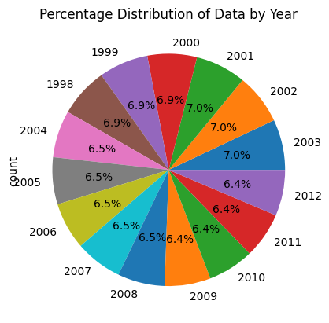

```python
a.plot(kind='pie', autopct='%1.1f%%') ## plot() creates a chart, kind = 'pie' tells o make a pie chart, autopct='%1.1f%%' → shows percentage values on the chart
plt.title("Percentage Distribution of Data by Year") ## Title for the chart
plt.show() ## Displays the chart
```

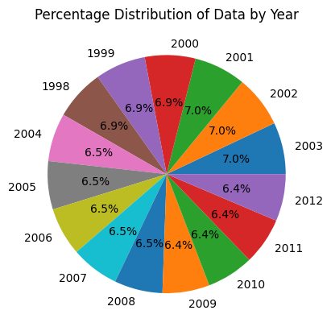

```python
a.plot(kind='pie', autopct='%1.1f%%') ## plot() creates a chart, kind = 'pie' tells o make a pie chart, autopct='%1.1f%%' → shows percentage values on the chart
plt.title("Percentage Distribution of Data by Year") ## Title for the chart
plt.ylabel("") ## removes the extra label on the Y axis
plt.show() ## Displays the chart
```

**Q4. Plot and Understand the distribution of the variable "price per lb" using displot, and write your findings.**

Displot means distribution plot.(Histogram)

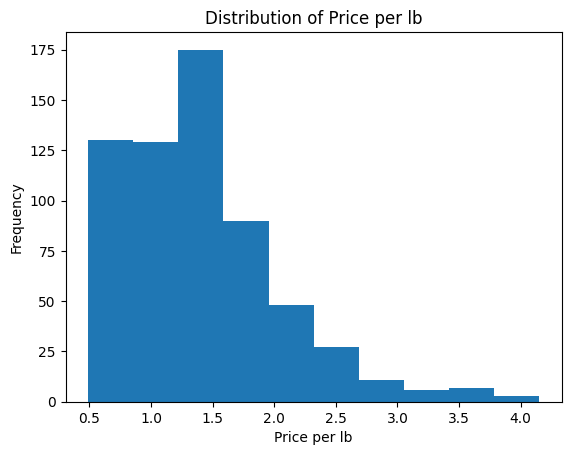

```python
## Matplotlib
plt.hist(df['priceperlb'], bins = 10)
plt.title("Distribution of Price per lb") ## Title for the chart
plt.xlabel("Price per lb")
plt.ylabel("Frequency")
plt.show() ## Displays the chart
```

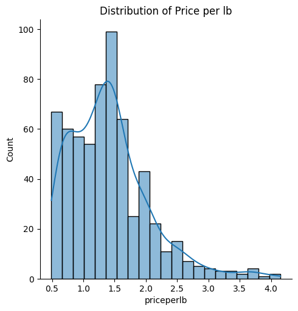

```python
## Seaborn
sns.displot(df['priceperlb'], kde=True) ##kde=True → Adds a smooth curve showing the data distribution.
plt.title("Distribution of Price per lb") ## Title for the chart
plt.show() ## Displays the chart
```

**Findings:** The distribution of the variable 'priceperlb' was visualized using **matplotlib and seaborn**. The plot shows how the price values are distributed. It indicates that **most of the values are concentrated in the lower price range, while a few of the values are concentrated in the high price range**. So it created a **right-skewed distribution**.

**Q5. Plot and understand the relationship between the variables 'numcol' and 'prodval' through scatterplot, and write your findings.**

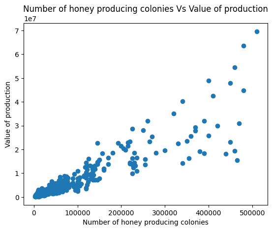

```python
##SCATTERPLOT
## Matplotlib
plt.scatter(df['numcol'], df['prodvalue'])
plt.xlabel("Number of honey producing colonies")
plt.ylabel("Value of production")
plt.title("Number of honey producing colonies Vs Value of production") ## Title for the chart
plt.show() ## Displays the chart
```

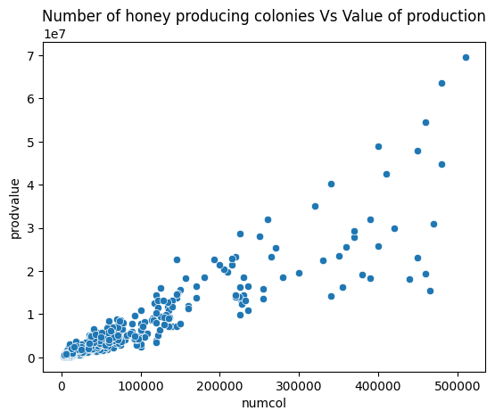

```python
## Seaborn
sns.scatterplot(x = "numcol", y = "prodvalue", data=df)
plt.title("Number of honey producing colonies Vs Value of production") ## Title for the chart
plt.show() ## Displays the chart
```

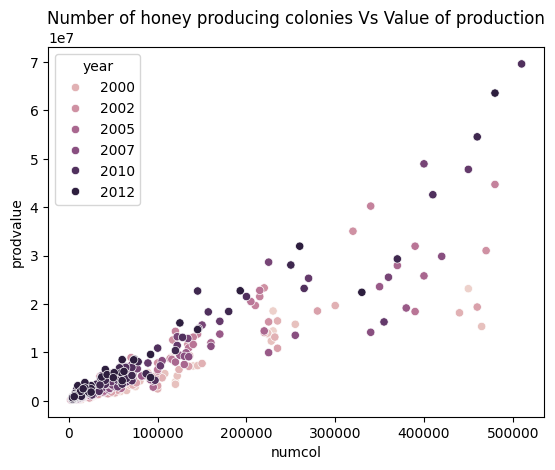

```python
sns.scatterplot(x = "numcol", y = "prodvalue", hue = "year", data=df)
plt.title("Number of honey producing colonies Vs Value of production") ## Title for the chart
plt.show() ## Displays the chart
```

**Q6. Plot and understand the relationship between categorical variable 'year' and a numerical variable 'prodvalue' through boxplot, and write your findings.**

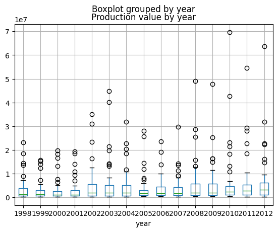

```python
##BOXPLOT
## Matplotlib
df.boxplot(column='prodvalue', by='year') ## In 'column' we want to store the numerical value, 'by' we want to store the data we want to group
plt.title("Production value by year") ## Title for the chart
plt.show() ## Displays the chart
```

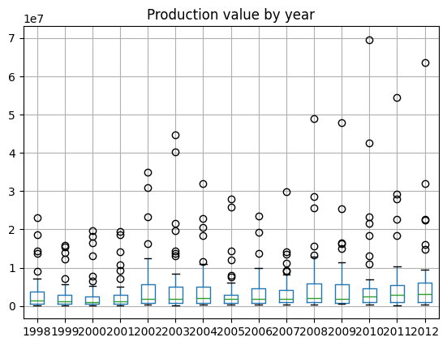

```python
plt.figure(figsize=(8,5)) ## used to set the size of the graph (figure) before plotting.
df.boxplot(column='prodvalue', by='year') ## In 'column' we want to store the numerical value, 'by' we want to store the data we want to group
plt.title("Production value by year") ## Title for the chart
plt.suptitle("") ## removes the subtitle
plt.xlabel("") ## removes the extra label on the Y axis
plt.show() ## Displays the chart
```

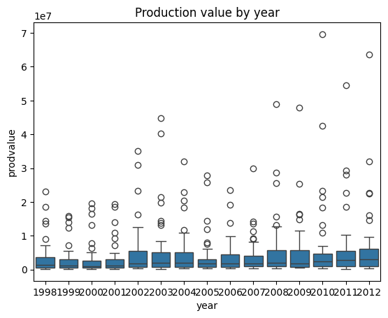

```python
##BOXPLOT
## Seaborn
sns.boxplot(x = "year", y = "prodvalue", data=df)
plt.title("Production value by year") ## Title for the chart
plt.show() ## Displays the chart
```

**Q7. Visualize and understand the relationship between the multiple pairs of variables throughout different years using pairplot and add your inferences. (use columns 'numcol', 'yield percol', 'total prod', 'prodvalue','year')**

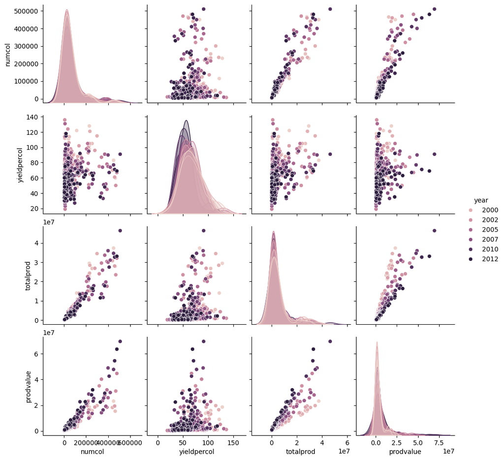

```python
sns.pairplot(df[['numcol','yieldpercol','totalprod','prodvalue','year']], hue='year')
plt.show()
```

**Findings:** Number of colonies increases Production value and total production also increases.

**Q8. Display the correlation values using a plot and add your inferences. (use columns 'numcol', 'yield percol', 'total prod', 'stocks', 'price per lb', 'prodvalue')**

```python
corr = df[['numcol','yieldpercol','totalprod','stocks','priceperlb','prodvalue']].corr() ##it shows the correlation
corr
```

|  | numcol | yieldpercol | totalprod | stocks | priceperlb | prodvalue |
| --- | --- | --- | --- | --- | --- | --- |
| numcol | 1.000000 | 0.243515 | 0.953594 | 0.825929 | -0.232701 | 0.912796 |
| yieldpercol | 0.243515 | 1.000000 | 0.396252 | 0.367812 | -0.358646 | 0.278977 |
| totalprod | 0.953594 | 0.396252 | 1.000000 | 0.878830 | -0.264499 | 0.907236 |
| stocks | 0.825929 | 0.367812 | 0.878830 | 1.000000 | -0.305867 | 0.728560 |
| priceperlb | -0.232701 | -0.358646 | -0.264499 | -0.305867 | 1.000000 | -0.089567 |
| prodvalue | 0.912796 | 0.278977 | 0.907236 | 0.728560 | -0.089567 | 1.000000 |

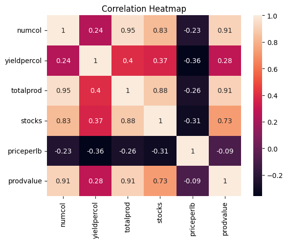

```python
sns.heatmap(corr,annot=True) ## Heatmap is used to check correlation. annot=True is used to displays the correlation values on the plot
plt.title("Correlation Heatmap")
plt.show()
```

**Findings:** The heatmap shows strong positive correlations between numcol, totalprod and prodvalue. It shows that High number of colonies and production levels leads to higher production value.